# Porównanie wykresu słupkowego i treemap

Maria Brzósko

# Wstęp i opis

W dzisiejszych czasach każdy z nas regularnie spotyka się z różnego rodzaju wykresami. Powszechnie wiadomo, że wybór odpowiedniego typu wizualizacji może znacząco wpłynąć na sposób interpretacji danych. W niniejszym raporcie porównuję dwa typy wykresów: wykres słupkowy i wykres prostokątowy (treemap).

Wykres słupkowy opiera się na porównywaniu wysokości słupków, podczas gdy treemap przedstawia dane przez względne powierzchnie prostokątów. Głównym celem tej analizy jest sprawdzenie hipotezy, że wykres słupkowy cechuje się wyższą czytelnością niż treemap. W celu weryfikacji tej hipotezy przeprowadziłam krótką ankietę, w której uczestnicy mieli za zadanie odczytać konkretne wartości z obu rodzajów wykresów i ocenić je pod względem czytelności oraz przyciągania uwagi.

```r
df_raw <- read.csv("https://raw.githubusercontent.com/mini-pw/2021Z-DataVisualizationTechniques/master/labs/data/Pokemon.csv")[,-1]

df <- df_raw %>%
  filter(Type.1 %in% c("Fire", "Water", "Grass", "Poison", "Electric")) %>%
  mutate(Type = factor(Type.1, levels = c("Fire", "Water", "Grass", "Poison", "Electric")))

percentages <- df %>%
  group_by(Type) %>%
  summarise(Percentage = n() / nrow(df) * 100) %>%
  ungroup()

types <- unique(percentages$Type)
type_colors <- setNames(brewer.pal(length(types), "Set1"), types)
```

# Wykresy

Link do ankiety: https://forms.gle/CRkekMHaF13EywSg9.

## Wykres słupkowy

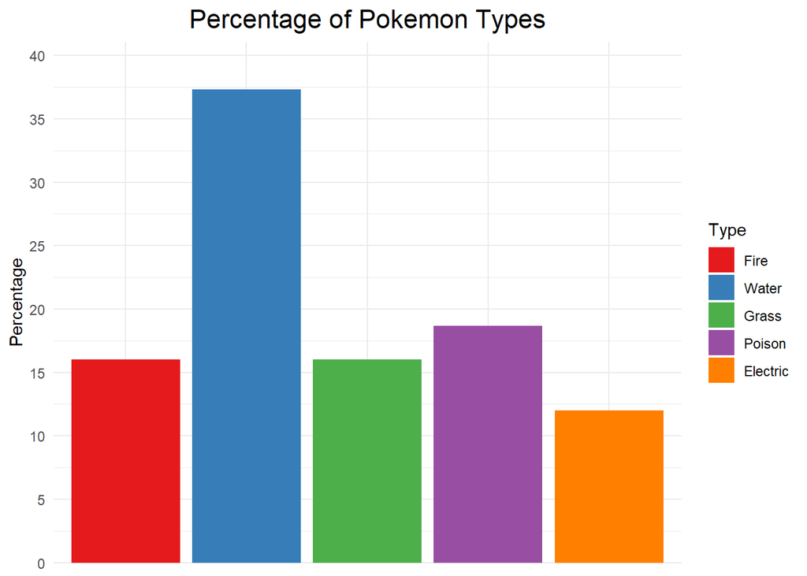

```r
ggplot(percentages, aes(x = Type, y = Percentage, fill = Type)) +
  geom_bar(stat = "identity") +
  labs(title = "Percentage of Pokemon Types", x = NULL, y = "Percentage", fill = "Type") +
  scale_y_continuous(breaks = seq(0, 100, by = 5),
                     expand = expansion(mult = c(0, 0.1))) +
  scale_fill_manual(values = type_colors) +
  theme_minimal() +
  theme(axis.text.x = element_blank(),
        axis.ticks.x = element_blank(),
        plot.title = element_text(hjust = 0.5, size = 16))
```

## Treemap

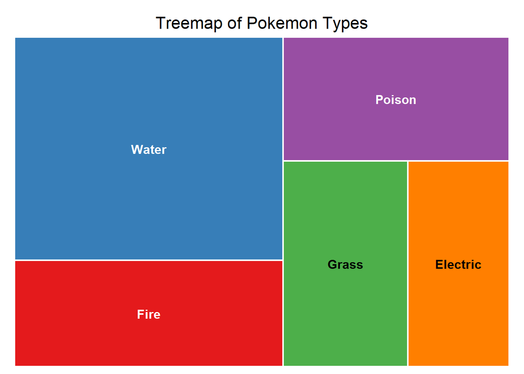

```r
treemap(df,
        index = "Type",
        vSize = "Total",
        vColor = "Type",
        palette = type_colors,
        draw = TRUE,
        title = "Treemap of Pokemon Types",
        border.col = "white",
        border.lwd = 2,
        fontsize.labels = 12,
        fontsize.title = 16)
```

# Analiza błędów odczytu danych z wykresów

W tej sekcji przedstawiam wyniki ankiety dotyczącej czytelności wykresów. Poprosiłam uczestników o odczytanie dwóch różnych wartości z każdego wykresu, a następnie obliczyłam bezwzględne błędy względem wartości rzeczywistych. Wyniki zestawiłam na wykresie skrzynkowym, który pozwala porównać dokładność odczytu dla obu typów wizualizacji.

Analiza jednoznacznie pokazuje, że wykresy słupkowe pozwalają na znacznie dokładniejszy odczyt - błędy były mniejsze i bardziej skupione wokół wartości rzeczywistych. W przypadku treemapy odchylenia były wyraźnie większe, co najprawdopodobniej wynika z trudności w szacowaniu powierzchni prostokątów, zwłaszcza gdy nie są one jednakowe ani ułożone w jednym rzędzie. Dodatkową zaletą wykresów słupkowych jest obecność osi liczbowej, która ułatwia wzrokowe porównywanie wysokości słupków.

Warto również zwrócić uwagę na pojedynczy outlier wśród odpowiedzi dotyczących wykresu słupkowego - był to przypadek odczytu ostatniego słupka, oddalonego od osi, co mogło utrudnić jego prawidłową ocenę.

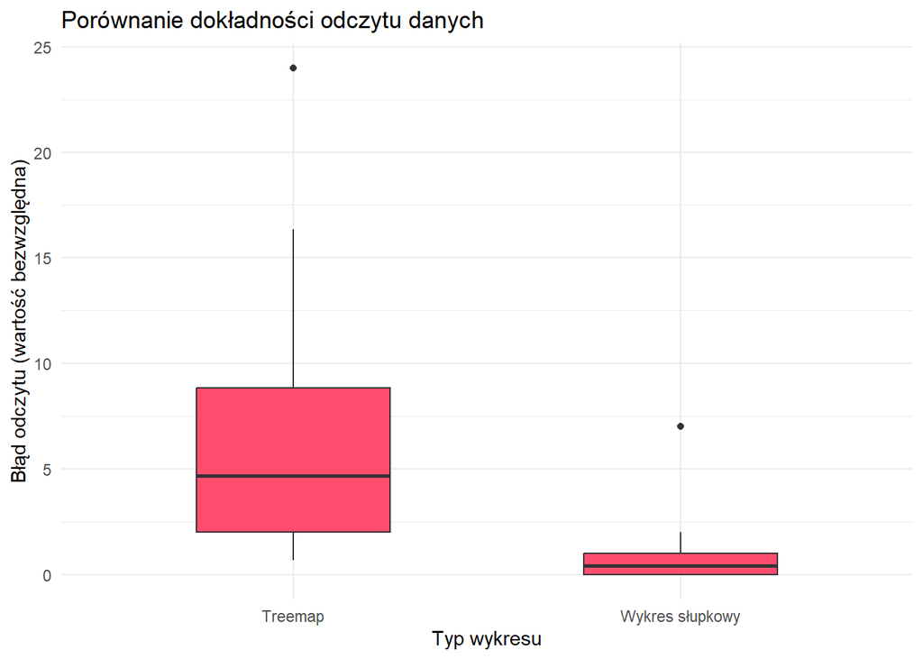

```r
# results <- read_excel("ankieta.xlsx") # tutaj zamiast wczytania wyników ankiety wpiszę je ręcznie, aby mogły się wyświetlić bez zapisanego pliku z wynikami
results <- data.frame(
  treemap_1 = c(18, 10, 12.5, 35, 18, 32.5, 16.66, 17, 11, 24, 10, 22, 28, 30, 18, 25),
  treemap_2 = c(18, 10, 10, 40, 20, 27, 12.5, 15, 14, 20, 14, 20, 27, 29, 19, 20),
  bar_1 = c(16, 17, 16, 17, 16, 17, 17, 16, 17, 17, 16, 15, 16, 16, 16, 16),
  bar_2 = c(12, 12.8, 12, 19, 12, 13, 14, 12.3, 12.5, 13, 11, 11, 13, 12, 12, 12),
  uwaga = c(2, 1, 1, 2, 2, 2, 1, 2, 1, 2, 1, 1, 2, 1, 2, 1),
  czytelnosc = c(2, 2, 2, 2, 2, 2, 2, 2, 2, 2, 2, 2, 2, 2, 2, 2))

results <- results %>%
  mutate(treemap_1_diff = abs(treemap_1 - percentages$Percentage[filter(percentages, Type == "Poison")$Type]),
         treemap_2_diff = abs(treemap_2 - percentages$Percentage[filter(percentages, Type == "Fire")$Type]),
         bar_1_diff = abs(bar_1 - percentages$Percentage[filter(percentages, Type == "Grass")$Type]),
         bar_2_diff = abs(bar_2 - percentages$Percentage[filter(percentages, Type == "Electric")$Type]))

results_long <- results %>%
  select(treemap_1_diff, treemap_2_diff, bar_1_diff, bar_2_diff) %>%
  pivot_longer(
    cols = everything(),
    names_to = "source",
    values_to = "diff"
  ) %>%
  mutate(
    plot_type = ifelse(str_detect(source, "treemap"), "Treemap", "Wykres słupkowy")
  )

ggplot(results_long, aes(x = plot_type, y = diff)) +
  geom_boxplot(width = 0.5, fill = "#ff4d6d") +
  labs(
    title = "Porównanie dokładności odczytu danych",
    x = "Typ wykresu",
    y = "Błąd odczytu (wartość bezwzględna)"
  ) +
  theme_minimal()
```

# Preferencje użytkowników: uwaga i czytelność

Kolejne pytania dotyczyły subiektywnej oceny wykresów. Uczestnicy mieli wskazać, który z nich bardziej przyciąga uwagę i który jest bardziej czytelny. Wszyscy jednogłośnie uznali, że wykres słupkowy jest czytelniejszy. W przypadku oceny atrakcyjności wizualnej zdania były podzielone. Pokazuje to, że wygląd wykresu nie zawsze decyduje o jego funkcjonalności - choć treemap robił dobre pierwsze wrażenie, to wykres słupkowy okazał się wyraźnie łatwiejszy w odbiorze.

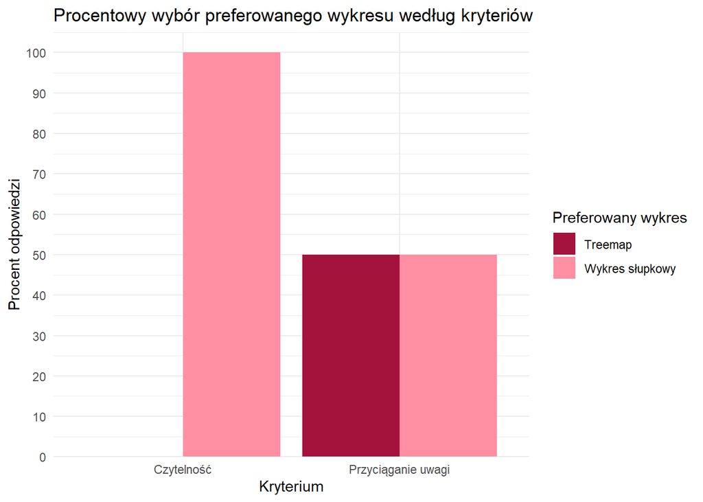

```r
results_long_c <- results %>%
  select(uwaga, czytelnosc) %>%
  pivot_longer(cols = everything(), names_to = "kryterium", values_to = "wybor") %>%
  mutate(
    wybor = factor(wybor, levels = c(1, 2), labels = c("Treemap", "Wykres słupkowy")),
    kryterium = recode(kryterium,
                       uwaga = "Przyciąganie uwagi",
                       czytelnosc = "Czytelność"))

results_percent <- results_long_c %>%
  count(kryterium, wybor) %>%
  group_by(kryterium) %>%
  mutate(procent = 100 * n / sum(n)) %>%
  ungroup()

results_final <- results_percent %>%
  complete(kryterium, wybor, fill = list(n = 0, procent = 0))

ggplot(results_final, aes(x = kryterium, y = procent, fill = wybor)) +
  geom_col(position = "dodge") +
  labs(
    title = "Procentowy wybór preferowanego wykresu według kryteriów",
    x = "Kryterium",
    y = "Procent odpowiedzi",
    fill = "Preferowany wykres") +
  scale_fill_manual(values = c("Treemap" = "#a4133c", "Wykres słupkowy" = "#ff8fa3")) +
  scale_y_continuous(breaks = seq(0, 100, 10), expand = expansion(mult = c(0, 0.05))) +
  theme_minimal()
```

# Podsumowanie

Na podstawie przeprowadzonej analizy można potwierdzić postawioną na początku hipotezę:

- Wykres słupkowy cechuje się większą precyzją i lepszą czytelnością niż treemap.
- Choć treemap może przyciągać uwagę, jego trudniejsza interpretacja ogranicza jego przydatność w dokładnej analizie danych.

Analiza wskazuje również, że atrakcyjność wizualna nie może zastąpić przejrzystości – warto o tym pamiętać przy projektowaniu wizualizacji danych.